# Using Simple Models to Explain Ecosystem Patterns

Adam N. Wlostowski

2020/03/01

**STILL UNDER CONSTRUCTION**

Simple (mathematical) models are useful learning tools. Given a set of observations, we use models to explain emergent patterns in the data. In this sense, models are hypotheses in the form of equations. If a model can reproduce patterns in the data, the hypothesis might not be wrong. However, if the model cannot explain the observations, the hypothesis is rejected, and we go back to the drawing board. Either way, we learn!

In this post, I illustrate the power of simple models in the context of river ecosystems. I begin by identifying a pattern. Then, I borrow a hypothesis from the literature to explain the pattern. Finally, I mathematically formalize the hypothesis and test it by seeing if the model can recreate the pattern.

It is necessary to provide some background on stream ecology and Antarctic rivers. I apologize if the background is too dense. I’ve embedded links along the way that direct to you to sources where you can learn more.

# Background

## Nitrogen Spiraling

Nitrogen (N) is a fundamental building block of ecosystems. It is an essential nutrient for life on earth, along with carbon and phosphorous. Understanding N fate and transport provides insight into how ecosystems operate. Nutrient spiraling theory provides a framework for understanding how N moves through river ecosystems. The spiral begins with downstream transport of an inorganic N species dissolved in flowing waters. Organisms in need of inorganic N assimilate it into their organic matter. Eventually, organic matter decomposition by microbes mineralizes inorganic N back into the water column. The spiral is complete.

Nitrogen spiraling is extremely well studied. Uptake and assimilation of inorganic N is one of the best-understood parts of N cycles. This is partially because inorganic N is a pollutant, so assimilation (retention) can be beneficial. However, the fate of assimilated N remains poorly resolved, hampering our ability to close ecosystem N budgets.

## The McMurdo Dry Valleys, Antarctica

As it turns out, rivers in the McMurdo Dry Valleys of Antarctica are excellent end-member systems for studying the fate and transport of assimilated N. A few key points you need to know about Antarctic rivers:

- The McMurdo Dry Valleys are one of the coldest and driest places on earth. In this region it is too cold to rain and most snowfall sublimates before melting.
- Glacial melt is the primary source of flow in Antarctic rivers. Rivers are hydrologically disconnected from adjacent hillslopes.
- Algae are some of the only primary producers found in the region. Rivers are an ideal habitat for algae, which form in mats on the riverbed. There are three types of algae mats. Orange and green mats live in the water column. Black mats live along channel edges.
- Black mats are nitrogen fixers (i.e. they can assimilate N<sub>2</sub> gas from the atmosphere).
- Nitrogen in the stream comes from glacier melt or in-stream N fixation (by black mats). Very little N comes from adjacent hillslopes. This is unusual. In most places on earth, streams get a lot of N (and water) from adjacent hillslopes.
- High flows scour algal mats from the streambed. This is a key mechanism controlling particulate organic matter (POM) concentration.
- Hyporheic zone interactions are extensive. Surface water is constantly mixing with shallow groundwater along the course of the stream.

## Nitrogen Isotopes

Nitrogen isotopes help to track N moving through river ecosystems. Isotopes are atoms with differing numbers of neutrons. Nitrogen has two stable isotopes; <sup>14</sup>N and <sup>15</sup>N. δ<sup>15</sup>N is the ratio <sup>15</sup>N:<sup>14</sup>N. As N moves through different components of the nutrient spiral, the value of δ<sup>15</sup>N increases and decreases. This makes δ<sup>15</sup>N a useful tracer for tracking the fate and transport of N.

The nitrogen isotope profile of Antarctic rivers is constrained by two end-members. On one hand, black mats are N fixers, so they have δ<sup>15</sup>N signature near the atmospheric standard (δ<sup>15</sup>N ≅ 0 per-mil). On the other hand, atmospheric deposition is the primary source of N in glacier ice. Therefore, glacier ice is characteristically depleted in δ<sup>15</sup>N (from -9.5 to -26.2 per-mil).

# Data

```r
# Load observations
dat <- read.csv("relict_channel_data.csv")

# look at the data
head(dat)
```

|  | stream | date_sampled | time_sampled | transect | sample_type | distance | d13C | d15N | CN | CP | NP | AFDM | chla | AI |
| --- | --- | --- | --- | --- | --- | --- | --- | --- | --- | --- | --- | --- | --- | --- |
| 1 | Relict_Channel | 20-Jan-13 | NA | RC0 | orange | 1.5350 | -21.63033 | -6.109830 | 9.378347 | 20.78049 | 2.215795 | NA | NA | NA |
| 2 | Relict_Channel | 20-Jan-13 | NA | RC0 | orange | 1.5350 | -20.68195 | -5.511347 | 9.180085 | 14.15511 | 1.541937 | NA | NA | NA |
| 3 | Relict_Channel | 20-Jan-13 | NA | RC1 | orange | 1.5725 | -18.34956 | -4.033698 | 11.165297 | 31.17973 | 2.792557 | 6.960352 | 2.353515 | 0.3381315 |
| 4 | Relict_Channel | 20-Jan-13 | NA | RC1 | orange | 1.5725 | -20.03926 | -3.656960 | 10.689993 | 20.63252 | 1.930078 | 5.462555 | 5.652732 | 1.0348147 |
| 5 | Relict_Channel | 20-Jan-13 | NA | RC2 | orange | 1.6795 | -18.87467 | -2.292846 | 9.213805 | 76.14598 | 8.264336 | 11.365639 | 15.217906 | 1.3389398 |
| 6 | Relict_Channel | 20-Jan-13 | NA | RC2 | orange | 1.6795 | -19.37847 | -1.096627 | 8.987226 | 38.20031 | 4.250512 | 11.850220 | 11.279305 | 0.9518224 |

# Pattern

One pattern observed in the data is an upstream to downstream enrichment of orange mat δ<sup>15</sup>N. The pattern is asymptotic. The furthest upstream samples are depleted in δ<sup>15</sup>N and resemble glacial water. Moving downstream, samples become enriched in δ<sup>15</sup>N, and approach the signature of atmospheric N (δ<sup>15</sup>N ≅ 0 per-mil).

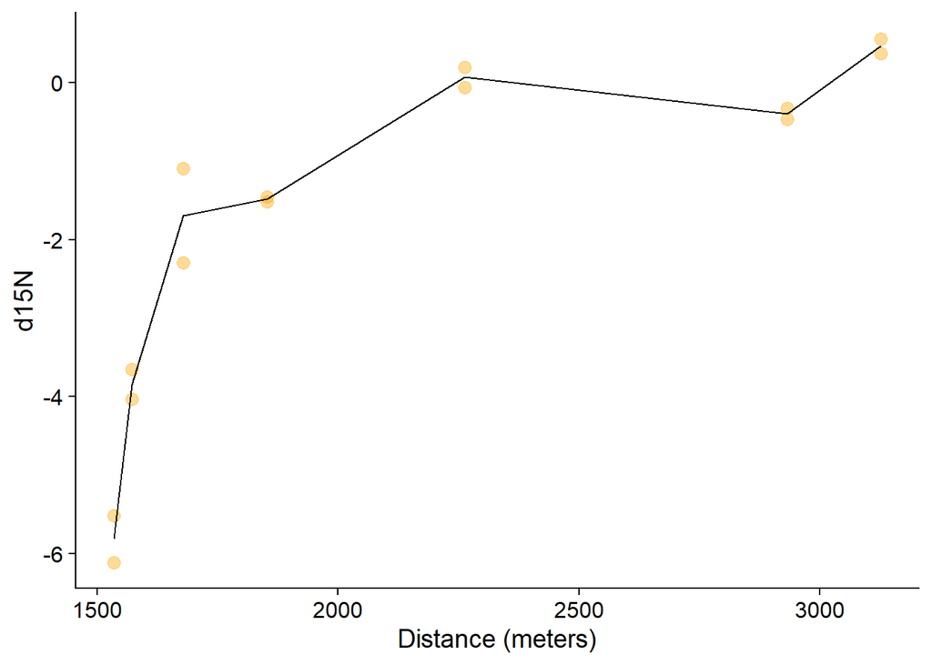

```r
# mean d15N at each station
d15N.av <- dat %>%
  group_by(distance) %>%
  summarize(dist = mean(distance),
            d15N = mean(d15N))

# Plot longitudinal 15N pattern
p <- ggplot(dat, aes(x = distance*1000, y = d15N)) +
  geom_point(size = 3, color = "orange", alpha = 0.4) +
  geom_line(data = d15N.av, aes(x = distance*1000, y = d15N)) +
  labs(x = "Distance (meters)")

print(p)
```

# Hypothesis

Tyler and his co-authors put forward a hypothesis to explain the asymptotic enrichment of δ<sup>15</sup>N. The hypothesis may be frames as a series of events:

First high flows scour black mats at the channel margin. Then mat-derived POM is transported downstream and stored in the hyporheic zone. Hyporheic microbes mineralize black mat POM and produce inorganic N. Finally, exchange flows flush inorganic N from the hyporheic zone into the open channel. As a result, inorganic N mineralized from black mats becomes a progressively larger source of available N with distance downstream.

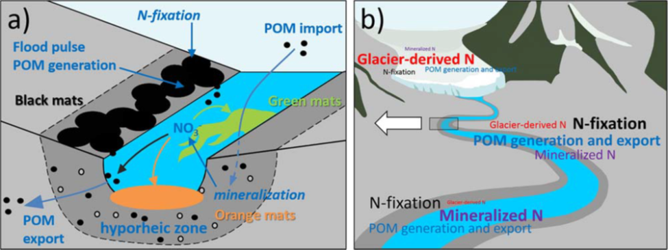

A conceptual diagram of N spiraling in Antarctic rivers.(a) N-fixing black mats grow at margins and generate POM during high flow events, which are exported downstream. POM is minearlized in the hyporheic zone, releasing inorganic N for uptake by downstream mats. (b) Upstream locations have the greatest concentrations of glacier-derived N and low mat biomass. As mat abundance increases downstream, glacier-derived N is exhausted, and N mineralized from black mats becomes the dominant N source. The relative magnitude of each processes is illustrated with text size. Figure and caption from Kohler et al., (2018)

# Model

Can this hypothesis explain the asymptotic enrichment pattern? I formalized the hypothesis with a mathematical model. The model simulates downstream changes in glacier- and black-mat derived inorganic N concentrations. It is a system of two ordinary differential equations. The Equation 1 represents the spatial rate of change in glacier-derived inorganic N. Equation 2 represents the spatial rate of change in black mat-derived inorganic N.

$$\begin{align}
\frac{dN_g}{dx}=-\lambda(\frac{N_g^2}{N_g+N_b})
\end{align}$$
$$\begin{align}
\frac{dN_b}{dx}=\phi-\lambda(\frac{N_b^2}{N_g+N_b})
\end{align}$$

Where *N<sub>g</sub>* is the concentration of glacier-derived inorganic N (micro grams per liter), *N<sub>b</sub>* is the concentration of black mat-derived inorganic N (micro grams per liter), λ is the inorganic N uptake rate of orange mats (per meter), *ϕ* is the flux of inorganic N from the hyporheic zone to the stream (micro grams per liter per meter), and *x* is channel distance (m).

The δ<sup>15</sup>N is calculated as

$$\begin{align}
\delta^{15}N=\frac{(\delta^{15}N_b \times N_b+\delta^{15}N_g \times N_g)}{N_b + N_g}
\end{align}$$

Where δ<sup>15</sup>N<sub>b</sub> is the nitrogen isotopic signature of black mat, and δ<sup>15</sup>N<sub>g</sub> is the nitrogen isotopic signature of glacier ice.

```r
# model equations
model <- function(distance, state, parameters) {
  par <- as.list(c(state, parameters))
  with(par, {

    dNg <- -lambda * (Ng^2/(Ng + Nb))           # Change is glacier-derived nitrogen with distance
    dNb <- phi - (lambda * (Nb^2/(Nb + Ng)))    # change in black mat derived nitrogen with distance

    list(c(dNg, dNb))
  })
}
```

# Insights

## Model Optimization

First we need to establish the model domain, initial conditions, and δ<sup>15</sup>N signatures of glacier ice and black mats.

- **Check with Diane about value of boundary conditions, what is reasonable for glacier ice DIN (Ng)?**

```r
# initialize the model domain, channel distance in meters
dist = seq(1530,4000,by = 1)

# initial conditions, N-species compositions at the upper boundary condition.
init <- c(Ng = 10,  # concentration of nigrogen in glacier ice (ug/L)
          Nb = 1)   # concentration of black-mat derived N at x = 0

# end members: delN-15 concentrations in black mats and glacier ice
n15g = -10
n15b = 0
```

```r
# Objective function - root mean squared error on d15N
RSS <- function(parameters) {

  names(parameters) <- c("phi", "lambda")

  # run the ode system
  out <- ode(y = init, # initial conditions
             times = dat$distance * 1000, # distance (converted from km to m)
             func = model, # the system of odes
             parms = parameters) # parameter values

  fit <- data.frame(out)

  fit <- fit %>%
    mutate(n15 = ((n15g * Ng) + (n15b * Nb))/(Ng + Nb))

  # return: RMSE with respect to d15N
  sum((dat$d15N - fit$n15)^2)

}
```

Now, we can optimize the model using the `optim` function from the `stats` package.

```r
# optimize with some sensible conditions
Opt <- optim(c(0.2, 1),          # initial guess
             RSS,                  # objective function
             method = "L-BFGS-B",  # optimization routine
             lower = c(0, 0),      # lower bound of search range
             upper = c(1, 1))      # upper bound of search range

Opt_par <- setNames(Opt$par, c("phi", "lambda")) # rename the optimal parameter set

print(Opt_par)
```

```
##        phi     lambda
## 0.24024553 0.03580479
```

**Are these parameter values reasonable? The assimilation rate is about an order of magnitude greater than that for Green Creek (McKnight et al., 2004). Maybe this is justified by the abundance of mats in Relict Channel and the fact that the channel rarely sees flow?**

Let’s plot the modeled and observed δ<sup>15</sup>N patterns.

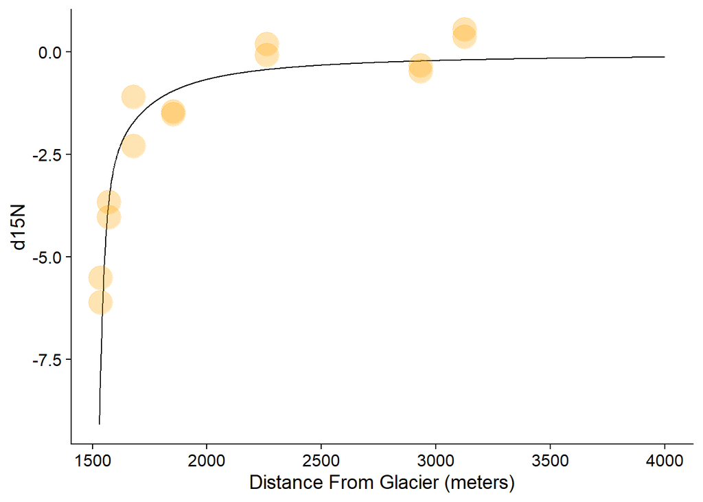

```r
fit <- data.frame(ode(y = init, times = dist, func = model, parms = Opt_par))

fit <- fit %>%
  mutate(n15 = ((n15g * Ng) + (n15b * Nb))/(Ng + Nb))

p <- ggplot(fit, aes(time, n15)) +
  geom_line() +
  geom_point(data = dat, aes(x = distance*1000, y = d15N), color = "orange", size = 8, alpha = 0.3) +
  labs(x = "Distance From Glacier (meters)",
       y = "δ15N")

print(p)
```

Let’s plot the modeled concentrtions of glacier- and black mat-derived inorganic nitrogen

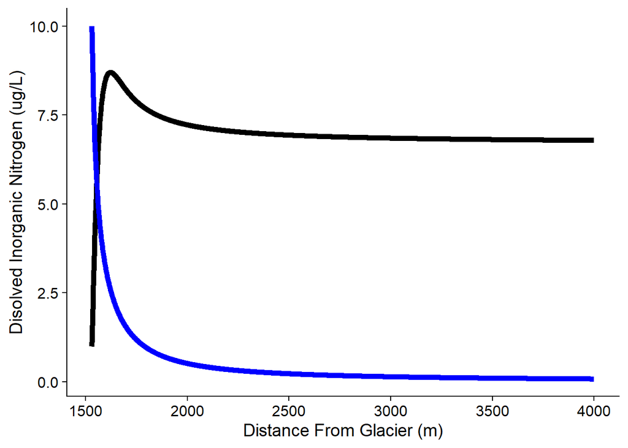

```r
p <- ggplot(fit, aes(time, Nb)) +
  geom_line(color = "black", size = 2) +
  geom_line(data = fit, aes(time, Ng), color = "blue", size = 2) +
  labs(x = "Distance From Glacier (m)",
       y = "Disolved Inorganic Nitrogen (ug/L)")

print(p)
```